# VIPER tests and hack for comparable samples

A. Gabor

8/19/2020

## Data

```r
summary(transcriptomics_data)
```

```
##     fileID          concentration       time    ensembl_gene_id
##  Length:272880      Min.   :  10   Min.   :24   Length:272880
##  Class :character   1st Qu.:  10   1st Qu.:24   Class :character
##  Mode  :character   Median : 100   Median :48   Mode  :character
##                     Mean   : 370   Mean   :48
##                     3rd Qu.:1000   3rd Qu.:72
##                     Max.   :1000   Max.   :72
##
##     baseMean        log2FoldChange          lfcSE              stat
##  Min.   :     4.4   Min.   :-8.943128   Min.   :0.05628   Min.   :-35.87551
##  1st Qu.:    31.8   1st Qu.:-0.325326   1st Qu.:0.16602   1st Qu.: -1.30249
##  Median :   123.8   Median : 0.006075   Median :0.23285   Median :  0.02435
##  Mean   :   627.1   Mean   :-0.038206   Mean   :0.29800   Mean   : -0.13825
##  3rd Qu.:   375.5   3rd Qu.: 0.335658   3rd Qu.:0.37071   3rd Qu.:  1.30043
##  Max.   :461342.0   Max.   : 8.137842   Max.   :1.74341   Max.   : 28.45794
##
##      pvalue             padj          organ            sample_id
##  Min.   :0.00000   Min.   :0.000   Length:272880      Length:272880
##  1st Qu.:0.01041   1st Qu.:1.000   Class :character   Class :character
##  Median :0.19321   Median :1.000   Mode  :character   Mode  :character
##  Mean   :0.30677   Mean   :0.876
##  3rd Qu.:0.56077   3rd Qu.:1.000
##  Max.   :1.00000   Max.   :1.000
##                    NA's   :10088
```

## Viper tests

#### VIPER is deterministic (runs are identical)

- test if results are deterministic (multiple runs and comparison)

```r
viper_input = dorothea_data_hgnc  %>%
    spread(sample_id,log2FC) %>%
    column_to_rownames("hgnc_symbol")

tf_activities_stat_1 <- dorothea::run_viper(viper_input, regulons,
    options =  list(minsize = 5, eset.filter = FALSE,
    cores = 1, verbose = FALSE, nes = TRUE),)

tf_activities_stat_2 <- dorothea::run_viper(viper_input, regulons,
    options =  list(minsize = 5, eset.filter = FALSE,
    cores = 1, verbose = FALSE, nes = TRUE),)

all(tf_activities_stat_1 ==tf_activities_stat_2)
```

```
## [1] TRUE
```

#### Sample independence

check if removing/adding a column to data matrix changes the results. If columns are computed independently, results should not change

```r
viper_input = dorothea_data_hgnc  %>%
    spread(sample_id,log2FC) %>%
    column_to_rownames("hgnc_symbol")

tf_activities_stat_col13 <- dorothea::run_viper(viper_input[1:3], regulons,
    options =  list(minsize = 5, eset.filter = FALSE,
    cores = 1, verbose = FALSE, nes = TRUE),)


tf_activities_stat_col19 <- dorothea::run_viper(viper_input[1:9], regulons,
    options =  list(minsize = 5, eset.filter = FALSE,
    cores = 1, verbose = FALSE, nes = TRUE),)


all(tf_activities_stat_col13 == tf_activities_stat_col19[,1:3])
```

```
## [1] TRUE
```

TF activities computed based on 3 samples and based on 9 samples are the same for the overlapping samples. Therefore samples (columns) are computed independently.

#### Scaling has no effect

Does scaling the data influence results?

```r
viper_input = dorothea_data_hgnc  %>%
    spread(sample_id,log2FC) %>%
    column_to_rownames("hgnc_symbol")

tf_activities_stat_nominal <- dorothea::run_viper(viper_input, regulons,
    options =  list(minsize = 5, eset.filter = FALSE,
    cores = 1, verbose = FALSE, nes = TRUE),)

tf_activities_stat_scaled <- dorothea::run_viper(scale(viper_input), regulons,
    options =  list(minsize = 5, eset.filter = FALSE,
    cores = 1, verbose = FALSE, nes = TRUE),)


all(tf_activities_stat_nominal == tf_activities_stat_scaled)
```

```
## [1] TRUE
```

#### Sample comparison

```r
viper_input = dorothea_data_hgnc  %>%
    spread(sample_id,log2FC) %>%
    column_to_rownames("hgnc_symbol")

tf_activities_stat <- dorothea::run_viper(viper_input, regulons,
    options =  list(minsize = 5, eset.filter = FALSE,
    cores = 1, verbose = FALSE, nes = TRUE),)


tf_activities_stat <- tf_activities_stat %>%
    as.data.frame() %>%
    rownames_to_column(var = "GeneID") %>%
    gather(condition,NES,-GeneID) %>%
    arrange(NES)
```

#### Example: transcription factor ZNF263

In my analysis, I would like to see how the TF activity goes in time and across dose. So let’s plot how the NES evolves in the 2 organs:

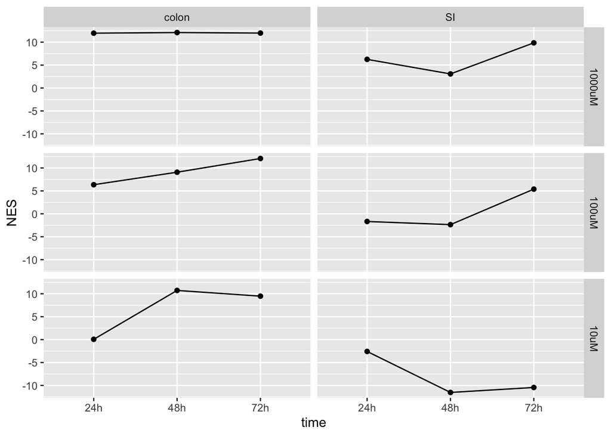

```r
NES_plot <- tf_activities_stat %>% filter(GeneID == "ZNF263") %>%
    separate(condition,into = c("organ","dose","time"),sep = "_") %>%
    ggplot(aes(time,NES)) +
    geom_point() +
    geom_line(aes(time,NES,group = organ)) +
    facet_grid(dose~organ)
print(NES_plot)
```

Note: this way of plotting is already misleading (!), because it assumes, we can compare the values across samples.  
I will show that this is not true.

Do the curves make sense? partially yes:

In colon: the higher the dose the stronger response we see in early time. However, the maximum of the NES is 10 across all concentrations in colon at 72 hours. This indicates, that the TF has the same activity in these conditions. But this is not true at all!

To see this, the following figure shows the log2FC of the target genes ofZNF263:

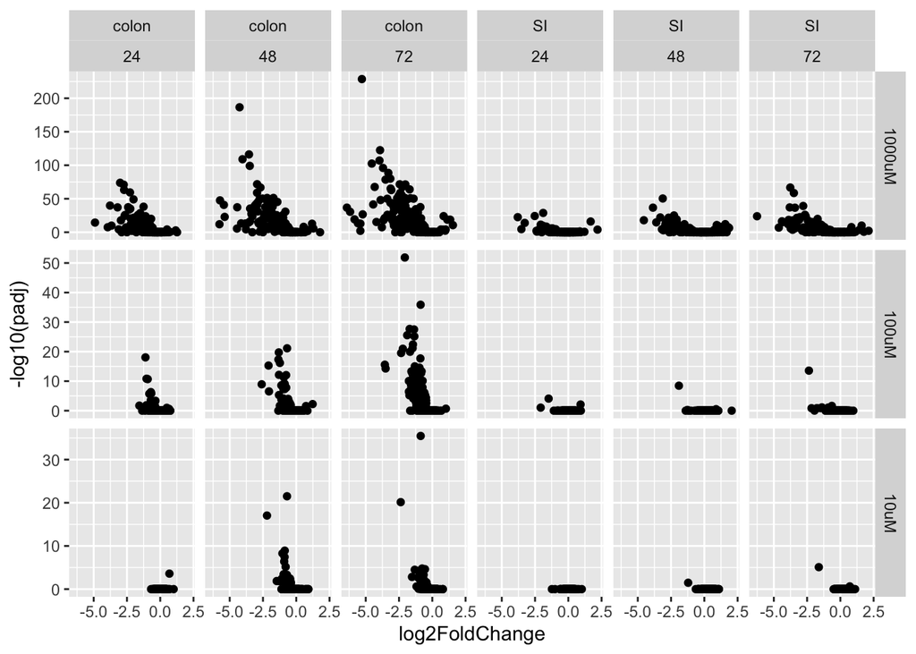

```r
dorothea_data %>%
    mutate(target = hgnc_symbol) %>%
    left_join(regulons,by = "target") %>%
    filter(tf=="ZNF263") %>%
    mutate(dose = paste0(concentration,"uM")) %>%
    ggplot() + geom_point(aes(log2FoldChange,-log10(padj))) + facet_grid(dose ~ organ + time, scales = "free_y")
```

Clearly, the target genes are more down-regulated when higher dose was applied.

If we compare Colon, at 72 hours, 1000uM vs 10uM, the log2FC are very different of the target genes, but the NES are around 10 in both cases.

This means that the NES cannot be compared between samples: the same NES can mean almost no change in target genes or a very strong change.

Let’s calculate a quantitative score for the transcription factor: for this we summarise the changes of it’s targets. Because the TF can inhibit/activate  
transcription, we also account for the sign of the interaction. So the score is the signed-corrected, average log2FC of the targets in each condition.

```r
tf_score <- dorothea_data %>%
    mutate(target = hgnc_symbol) %>%
    inner_join(regulons,by = "target") %>%
    group_by(tf, organ, concentration,time) %>%
    summarise(tf_score = mean(log2FoldChange*mor)) %>%
    ungroup()
```

Let’s compare the NES and the tf_score:

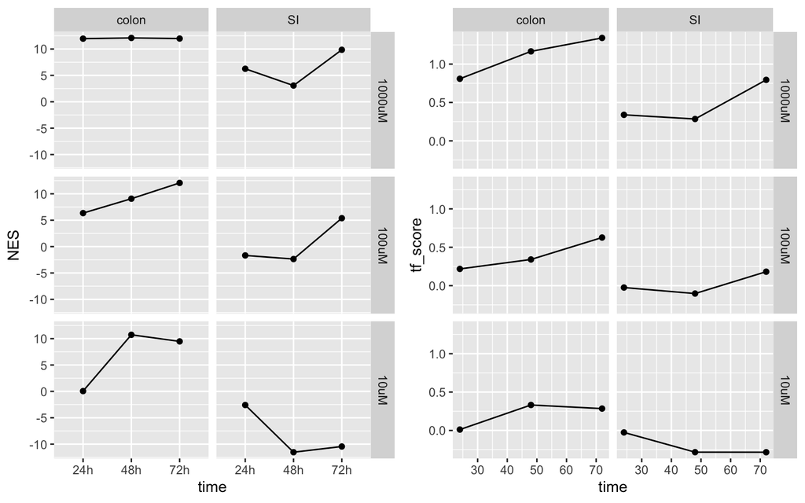

```r
tf_score_plot  = tf_score %>% filter(tf == "ZNF263") %>%
    mutate(dose = paste0(concentration,"uM")) %>%
    ggplot(aes(time,tf_score)) +
    geom_point() +
    geom_line(aes(group = organ)) +
    facet_grid(dose~organ)

cowplot::plot_grid(NES_plot,tf_score_plot )
```

The trends are similar, but notice, that a tf_score of 0.25 (colon, 10uM, 72h) and a tf_score of 1.25 (colon, 1000uM, 72h) are both have NES around 10!

## Establishing a global null-distribution

The problem with the NES is that VIPER is based on ranking in the respective sample. Therefore a geneset gets a score based on how the elements are ranked in a sample. We could force Viper to rank the genes across **all** samples. This trick can be done by extending each columns with all the samples.

This way when VIPER generates null-distributions where all the samples are included.

```r
# skip_one_merge
#
# returns a dataframe, where each column contains all, but the i-th column of
# the data from the original dataframe
# input: data.frame
#
skip_one_merge <- function(df){

    dat = tibble()

    rb <- lapply(seq(ncol(df)),function(i){
        tmp = tibble(col = unlist(df[,-i]))
        colnames(tmp) = colnames(df)[i]
        return(tmp)
    } )
    lrb <- bind_cols(rb) %>% as.data.frame()

    rownames(lrb) = paste(rep(rownames(df),ncol(df)-1), rep(1:(ncol(df)-1),each=nrow(df)),sep = "_")
    return(lrb)
}

# data frame with the original data
viper_input = dorothea_data_hgnc  %>%
    spread(sample_id,log2FC) %>%
    column_to_rownames("hgnc_symbol")

# reference: each column contains all the expression data, therefore, when TFs are
# ranked by the log2FC of their targets, all samples are considered:
reference_log2fc = skip_one_merge(viper_input)


# run viper:
viper_w_ref = bind_rows(viper_input,reference_log2fc)
tf_activities_stat_w_ref <- dorothea::run_viper(viper_w_ref, regulons,
    options =  list(minsize = 5, eset.filter = FALSE,
    cores = 1, verbose = FALSE, nes = TRUE),)

global_tf_activities_stat <- tf_activities_stat_w_ref %>%
    as.data.frame() %>%
    rownames_to_column(var = "GeneID") %>%
    gather(condition,gNES,-GeneID) %>%
    group_by(condition) %>%
    arrange(gNES)
```

Let’s compare the this new enrichment score that I call gNES with the old NES and tf_score:

```
## geom_path: Each group consists of only one observation. Do you need to adjust
## the group aesthetic?
```

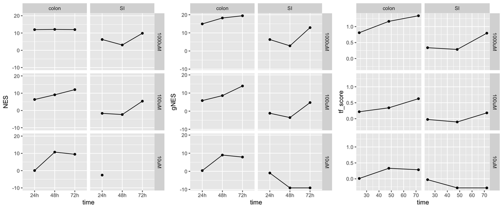

```r
global_NES_plot <- global_tf_activities_stat %>%
    filter(GeneID == "ZNF263") %>%
    separate(condition,into = c("organ","dose","time"),sep = "_") %>%
    ggplot(aes(time,gNES)) +
    geom_point() +
    geom_line(aes(group = organ)) +
    facet_grid(dose~organ)

cowplot::plot_grid(NES_plot + ylim(-10,20) ,global_NES_plot, tf_score_plot,nrow = 1 )
```

Notice the subtle differences:

in colon, 10uM, both NES and gNES reach a value of 10. However, in 1000 uM the gNES curve starts at 15 and reaches 20 at 72 hours. Also the difference between the 10uM and 1000uM conditions, that we see in the Vulcano plots above are visible in the gNES values (and was not based on the NES).

### Direct comparison NES/gNES vs tf_score:

```r
tf_stats <- full_join(global_tf_activities_stat %>% rename(tf = GeneID),
          tf_activities_stat %>% rename(tf = GeneID),by = c("tf", "condition")) %>%
            separate(condition,into = c("organ","concentration","time"),sep = "_") %>%
            full_join(tf_score %>% mutate(time = paste0(time,"h"),
                                          concentration = paste0(concentration,"uM")),
                      by = c("tf", "organ", "time","concentration"))
```

If we plot NES vs tf_score and gNES vs tf_score, it seems that NES saturates much earlier than gNES.

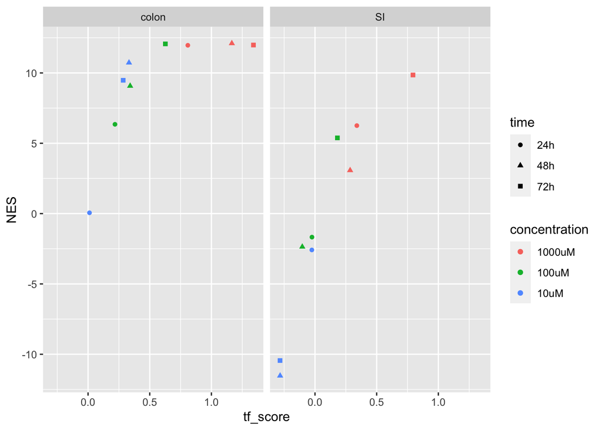

```r
tf_stats %>%
    filter(tf == "ZNF263") %>%
    ggplot(aes(tf_score,NES)) + geom_point(aes(col = concentration,shape=time)) + facet_wrap(~organ)
```

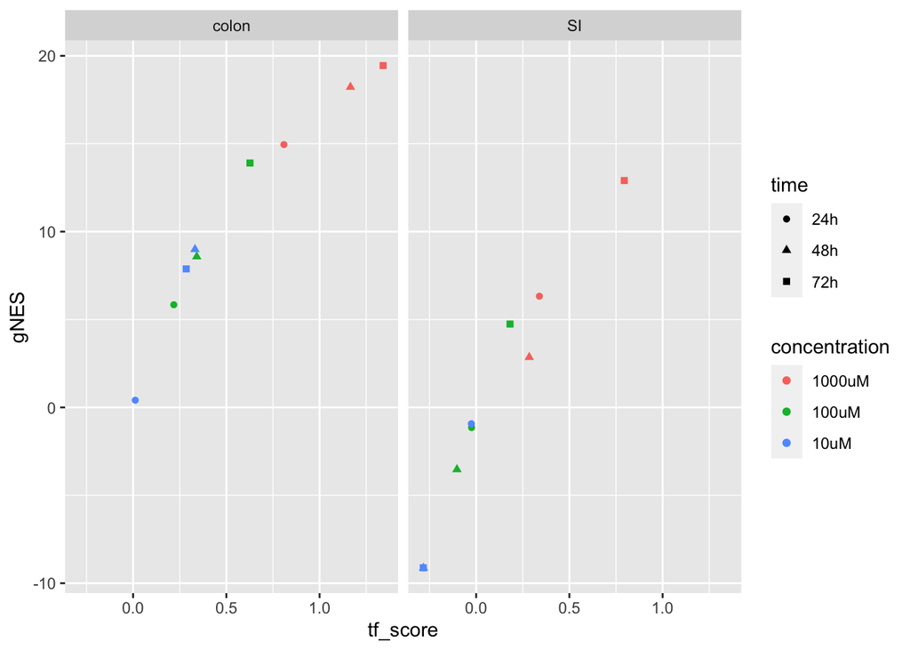

```r
tf_stats %>%
    filter(tf == "ZNF263") %>%
    ggplot(aes(tf_score,gNES)) + geom_point(aes(col = concentration,shape=time)) + facet_wrap(~organ)
```